# Practical Machine Learning Project Assignment

Somprabh Jha

February 9, 2018

## Overview

Six participants were asked to perform barbell lifts correctly and incorrectly in 5 different ways. In the “classe” variable an “A” corresponds to the correct execution of the exercise, while the other 4 classes (B through E) correspond to common mistakes. By using data from accelerometers on the belt, forearm, arm, and dumbell my goal is to predict which class the observation falls in.

So I first setup the needed environment and get the training & test datasets.

```r
library(caret)
library(rpart)
```

```r
library(rpart.plot)
library(RColorBrewer)
library(rattle)
library(randomForest)
library(knitr)
library(gbm)
library(e1071)
setwd("E:/DataScience/MachineLearning/Week4/ProgrammingAssignment")
trainUrl <- "https://d396qusza40orc.cloudfront.net/predmachlearn/pml-training.csv"
testUrl <- "https://d396qusza40orc.cloudfront.net/predmachlearn/pml-testing.csv"
training <- read.csv(url(trainUrl), na.strings=c("NA","#DIV/0!",""))
testing <- read.csv(url(testUrl), na.strings=c("NA","#DIV/0!",""))
```

## Preparing Data

```r
# Remove columns that have almost no variance in their values
nvtraining <- nearZeroVar(training, saveMetrics=TRUE)
mytrainingsub <- training[,nvtraining$nzv==FALSE]
nvtesting <- nearZeroVar(testing,saveMetrics=TRUE)
mytestingsub <- testing[,nvtesting$nzv==FALSE]

# Remove the first 6 (not predictors) columns from the training dataset
mytrainingsub <- mytrainingsub[,7:length(colnames(mytrainingsub))]

# Count the number of NAs in each col
nonnaCols <- as.vector(apply(mytrainingsub, 2, function(mytrainingsub) length(which(!is.na(mytrainingsub)))))
# Drop columns that have more than 50% NAs
dropNAs <- c()
for (i in 1:length(nonnaCols)) {
    if (nonnaCols[i] > nrow(mytrainingsub)*.50) {
        dropNAs <- c(dropNAs, colnames(mytrainingsub)[i])
    }
}
#drop NA data in training and testing
mytrainingsub <- mytrainingsub[,(names(mytrainingsub) %in% dropNAs)]
#remove classe as it's not contained in testing
keepcols <- colnames(mytrainingsub[, -53])
mytestingsub <- mytestingsub[keepcols]

# As we havea decent number of records I will create a test dataset for my testing
intrain <- createDataPartition(mytrainingsub$classe, p=0.6, list=FALSE)
mytrainingfin <- mytrainingsub[intrain, ]
mytestingfin <- mytrainingsub[-intrain, ]
```

## Model Analysis

First we will try the Decision Trees model and analyse the results.

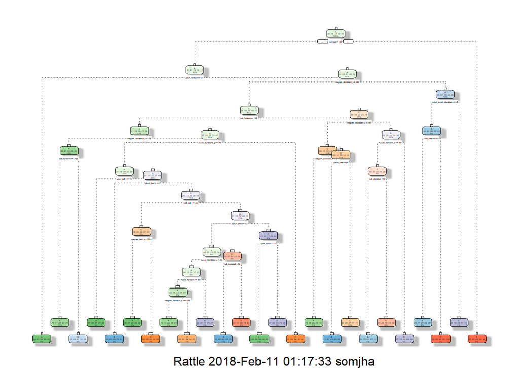

```r
set.seed(107)
moddt <- rpart(classe~., data=mytrainingfin, method="class")
fancyRpartPlot(moddt)
```

```r
predictionsdt <- predict(moddt, mytestingfin, type = "class")
cmdt <- confusionMatrix(predictionsdt, mytestingfin$classe)
cmdt
```

```
## Confusion Matrix and Statistics
##
##           Reference
## Prediction    A    B    C    D    E
##          A 2025  229   16   69   16
##          B   81  915   61   94  118
##          C   60  158 1106  186  191
##          D   28  121  106  831   97
##          E   38   95   79  106 1020
##
## Overall Statistics
##
##                Accuracy : 0.7516
##                  95% CI : (0.7419, 0.7611)
##     No Information Rate : 0.2845
##     P-Value [Acc > NIR] : < 2.2e-16
##
##                   Kappa : 0.6853
##  Mcnemar's Test P-Value : < 2.2e-16
##
## Statistics by Class:
##
##                      Class: A Class: B Class: C Class: D Class: E
## Sensitivity            0.9073   0.6028   0.8085   0.6462   0.7074
## Specificity            0.9412   0.9441   0.9082   0.9463   0.9503
## Pos Pred Value         0.8599   0.7210   0.6502   0.7025   0.7623
## Neg Pred Value         0.9623   0.9083   0.9574   0.9317   0.9352
## Prevalence             0.2845   0.1935   0.1744   0.1639   0.1838
## Detection Rate         0.2581   0.1166   0.1410   0.1059   0.1300
## Detection Prevalence   0.3002   0.1617   0.2168   0.1508   0.1705
## Balanced Accuracy      0.9242   0.7734   0.8583   0.7963   0.8288
```

Next we will try the Random Forests model and analyse the results.

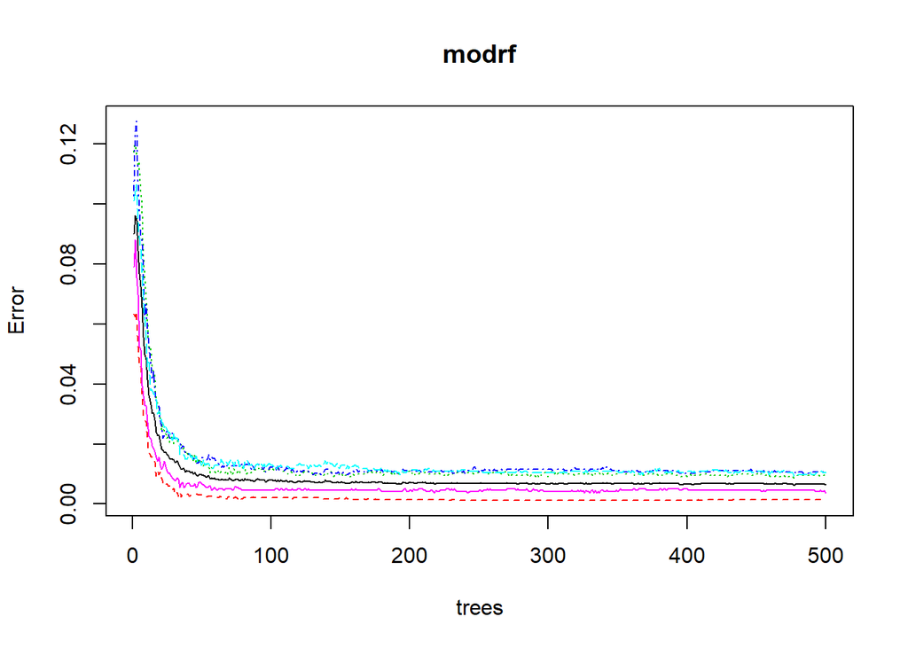

```r
set.seed(107)
modrf <- randomForest(classe ~ ., data=mytrainingfin)
plot(modrf)
```

```r
predictionrf <- predict(modrf, mytestingfin, type = "class")
cmrf <- confusionMatrix(predictionrf, mytestingfin$classe)
ooserr <- 1-cmrf$overall['Accuracy']
cmrf
```

```
## Confusion Matrix and Statistics
##
##           Reference
## Prediction    A    B    C    D    E
##          A 2229    7    0    0    0
##          B    3 1508    4    0    0
##          C    0    3 1362   22    1
##          D    0    0    2 1263    4
##          E    0    0    0    1 1437
##
## Overall Statistics
##
##                Accuracy : 0.994
##                  95% CI : (0.992, 0.9956)
##     No Information Rate : 0.2845
##     P-Value [Acc > NIR] : < 2.2e-16
##
##                   Kappa : 0.9924
##  Mcnemar's Test P-Value : NA
##
## Statistics by Class:
##
##                      Class: A Class: B Class: C Class: D Class: E
## Sensitivity            0.9987   0.9934   0.9956   0.9821   0.9965
## Specificity            0.9988   0.9989   0.9960   0.9991   0.9998
## Pos Pred Value         0.9969   0.9954   0.9813   0.9953   0.9993
## Neg Pred Value         0.9995   0.9984   0.9991   0.9965   0.9992
## Prevalence             0.2845   0.1935   0.1744   0.1639   0.1838
## Detection Rate         0.2841   0.1922   0.1736   0.1610   0.1832
## Detection Prevalence   0.2850   0.1931   0.1769   0.1617   0.1833
## Balanced Accuracy      0.9987   0.9962   0.9958   0.9906   0.9982
```

Lastly we will try Generalized Boosted Regresssion and analyse the results.

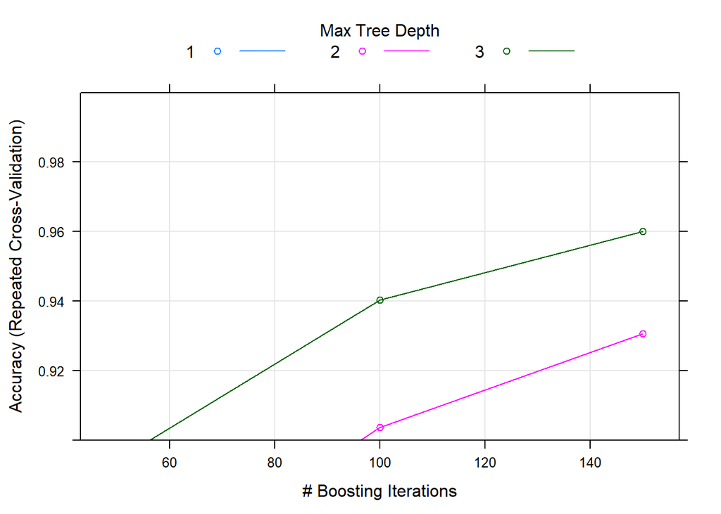

```r
set.seed(107)
fitControl <- trainControl(method="repeatedcv", number=5, repeats= 1)
gbmFit1 <- train(classe~., data=mytrainingfin, method="gbm", trControl=fitControl,
                 verbose=FALSE)
gbmFinMod1 <- gbmFit1$finalModel
plot(gbmFit1, ylim=c(0.9, 1))
```

```r
predictgbm <- predict(gbmFit1, newdata=mytestingfin)
cmgbm <- confusionMatrix(predictgbm, mytestingfin$classe)
cmgbm
```

```
## Confusion Matrix and Statistics
##
##           Reference
## Prediction    A    B    C    D    E
##          A 2194   50    0    2    2
##          B   26 1421   43    1   16
##          C    6   39 1307   41   15
##          D    4    5   17 1231   17
##          E    2    3    1   11 1392
##
## Overall Statistics
##
##                Accuracy : 0.9616
##                  95% CI : (0.9571, 0.9658)
##     No Information Rate : 0.2845
##     P-Value [Acc > NIR] : < 2.2e-16
##
##                   Kappa : 0.9515
##  Mcnemar's Test P-Value : 3.342e-07
##
## Statistics by Class:
##
##                      Class: A Class: B Class: C Class: D Class: E
## Sensitivity            0.9830   0.9361   0.9554   0.9572   0.9653
## Specificity            0.9904   0.9864   0.9844   0.9934   0.9973
## Pos Pred Value         0.9760   0.9429   0.9283   0.9662   0.9879
## Neg Pred Value         0.9932   0.9847   0.9905   0.9916   0.9922
## Prevalence             0.2845   0.1935   0.1744   0.1639   0.1838
## Detection Rate         0.2796   0.1811   0.1666   0.1569   0.1774
## Detection Prevalence   0.2865   0.1921   0.1795   0.1624   0.1796
## Balanced Accuracy      0.9867   0.9613   0.9699   0.9753   0.9813
```

## Conclusion

Random Forests gave an accuracy in the mytestingfin dataset of 0.9940097, which was more accurate than what I got from the Decision Trees (0.7515932) or GBM (0.9616365). The expected out-of-sample error is 0.0059903.

So let us select this model and apply it to the test dataset for the assignment

```r
predictiontest <- predict(modrf, testing, type = "class")
predictiontest
```

```
##  1  2  3  4  5  6  7  8  9 10 11 12 13 14 15 16 17 18 19 20
##  B  A  B  A  A  E  D  B  A  A  B  C  B  A  E  E  A  B  B  B
## Levels: A B C D E
```